# R Notebook

Name: Mayuri Patel

Email: mpate131@uncc.edu

title: “Lab7_AdvStats”

1. We again return to our RNA seq dataset of E. Coli genes from mice.  
   The URL is here: http://afodor.github.io/classes/stats2015/longitdunalRNASeqData.zip As before, read and normalize the counts table ( “nc101_scaff_dataCounts.txt “ into R). For example: setwd(”C:\somewhere")

myT<-read.table(“nc101_scaff_dataCounts.txt”,sep=",header=TRUE,row.names=1) ## remove rare genes myT <- myT[ apply( myT,1, median)> 5,]

myTNorm <- myT for ( i in 1:ncol(myT)) { colSum = sum(myT[,i]) myTNorm[,i] =myTNorm[,i]/colSum } (The first 3 columns are “day 2”, the next 3 columns are “week 12” and the last 5 are “week 18”).

- Reading the file of datacount from the directory:

```r
#set the working directory to the file location
setwd("C:/Users/mpate131/Desktop/AdvStats")

#read the table
myTable<-read.table("nc101_scaff_dataCounts.txt",sep="\t",header=TRUE,row.names=1)
head(myTable) #viewing the data using head function
```

|  | D2_01 | D2_02 | D2_03 | W12_01 | W12_02 | W12_03 | w20_01 | w20_02 | w20_03 | w20_04 | w20_05 |
| --- | --- | --- | --- | --- | --- | --- | --- | --- | --- | --- | --- |
| NC101_00003 | 329 | 29 | 40 | 97 | 423 | 141 | 469 | 342 | 884 | 713 | 52 |
| NC101_00004 | 30 | 2 | 6 | 7 | 83 | 34 | 76 | 45 | 131 | 127 | 65 |
| NC101_00005 | 145 | 53 | 23 | 122 | 271 | 128 | 102 | 57 | 134 | 112 | 13 |
| NC101_00006 | 510 | 80 | 54 | 156 | 717 | 193 | 489 | 228 | 536 | 487 | 57 |
| NC101_00007 | 5 | 3 | 0 | 13 | 25 | 1 | 9 | 2 | 30 | 9 | 11 |
| NC101_00008 | 14 | 4 | 2 | 8 | 65 | 14 | 208 | 82 | 302 | 241 | 14 |

- Normalize the data:

```r
# remove rare genes
myTable <- myTable[ apply( myTable,1, median)> 5,]

myTNorm <- myTable
#For loop each column
for ( i in 1:ncol(myTable))
{
    colSum = sum(myTable[,i]) # all rows and each column and summing all the column
    myTNorm[,i] =myTNorm[,i]/colSum # normalizing the data and saving it in the empty variable myTNorm.

}
head(myTNorm) #viewing the data using head function
```

|  | D2_01 | D2_02 | D2_03 | W12_01 | W12_02 | W12_03 | w20_01 | w20_02 | w20_03 | w20_04 | w20_05 |
| --- | --- | --- | --- | --- | --- | --- | --- | --- | --- | --- | --- |
| NC101_00003 | 5.680896e-04 | 1.838224e-04 | 5.226435e-04 | 3.748604e-04 | 3.906539e-04 | 3.327968e-04 | 3.955886e-04 | 4.990602e-04 | 5.194085e-04 | 4.562896e-04 | 7.653778e-05 |
| NC101_00004 | 5.180148e-05 | 1.267740e-05 | 7.839653e-05 | 2.705178e-05 | 7.665312e-05 | 8.024887e-05 | 6.410392e-05 | 6.566582e-05 | 7.697117e-05 | 8.127459e-05 | 9.567223e-05 |
| NC101_00005 | 2.503738e-04 | 3.359512e-04 | 3.005200e-04 | 4.714739e-04 | 2.502771e-04 | 3.021134e-04 | 8.603420e-05 | 8.317671e-05 | 7.873387e-05 | 7.167523e-05 | 1.913445e-05 |
| NC101_00006 | 8.806252e-04 | 5.070962e-04 | 7.055688e-04 | 6.028683e-04 | 6.621721e-04 | 4.555303e-04 | 4.124581e-04 | 3.327068e-04 | 3.149355e-04 | 3.116593e-04 | 8.389719e-05 |
| NC101_00007 | 8.633580e-06 | 1.901611e-05 | 0.000000e+00 | 5.023902e-05 | 2.308829e-05 | 2.360261e-06 | 7.591253e-06 | 2.918481e-06 | 1.762698e-05 | 5.759617e-06 | 1.619069e-05 |
| NC101_00008 | 2.417403e-05 | 2.535481e-05 | 2.613218e-05 | 3.091632e-05 | 6.002955e-05 | 3.304365e-05 | 1.754423e-04 | 1.196577e-04 | 1.774450e-04 | 1.542297e-04 | 2.060633e-05 |

1. For each row in the spreadsheet, perform a one-way ANOVA with categories “day 2”, “week 12” and “week 18”. Plot out the histogram of all p-values. How many genes are significant at a BH FDR-corrected 0.05 threshold.

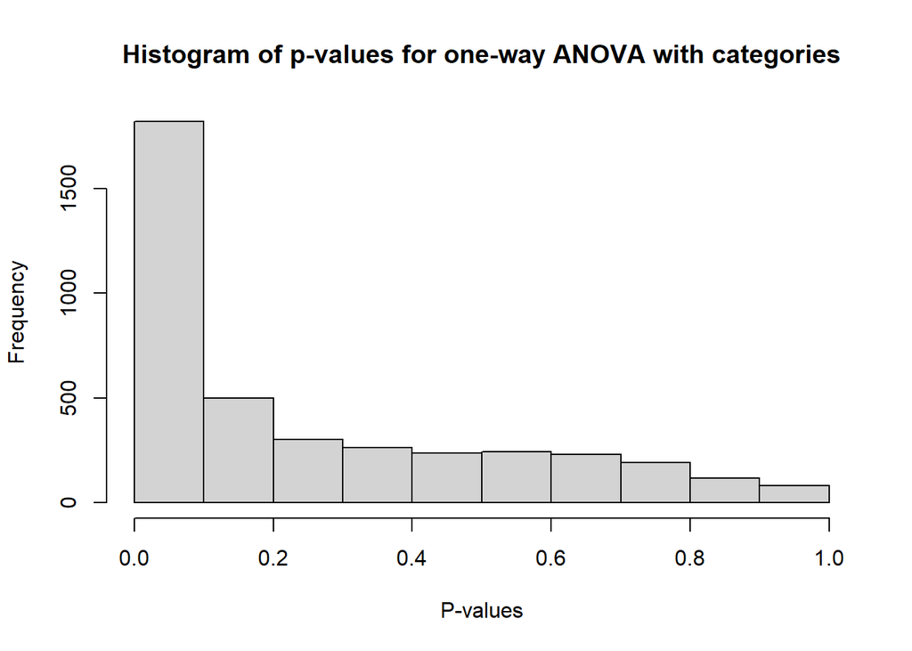

```r
#replicating the categories of the sample here.
categories_value <- c(rep("D2",3), rep("W12",3), rep("W20",5))

#empty variable to save the p values
anova_pVal <- c()

#get each row of data and cast it to numeric
for( i in 1:nrow(myTNorm)){
    myData <- as.numeric(myTNorm[i,] )

    ##  building linear models with myData as the y-variable and categories as x variable
    mylinearmodel <- lm(myData ~ categories_value, x=TRUE)
    anova_pVal <- c(anova_pVal, anova(mylinearmodel)$ "Pr(>F)"[1]) # extracting the p value from the linear model
}
# histogram of the p-values.
hist(anova_pVal,xlab = "P-values", ylab ="Frequency",main ="Histogram of p-values for one-way ANOVA with categories")
```

```r
#For p <0.05 BH FDR corrected:
anova_BH <- p.adjust(anova_pVal, method="BH") # using method BH
anova_BHpval <- sum(anova_BH<0.05) # summing all the p values <0.05
print(paste("The number of genes significant at p-values <0.05 BH FDR corrected for one-way ANOVA with categories “day 2”, “week 12” and “week 18” is :", anova_BHpval))
```

```
## [1] "The number of genes significant at p-values <0.05 BH FDR corrected for one-way ANOVA with categories “day 2”, “week 12” and “week 18” is : 612"
```

2. Next make an ANOVA as a linear regression as a function of time (so 2 days, 86 days and 128 days). Plot out the histogram of all p-values. How many genes are significant at a BH FDR-corrected 0.05 threshold.

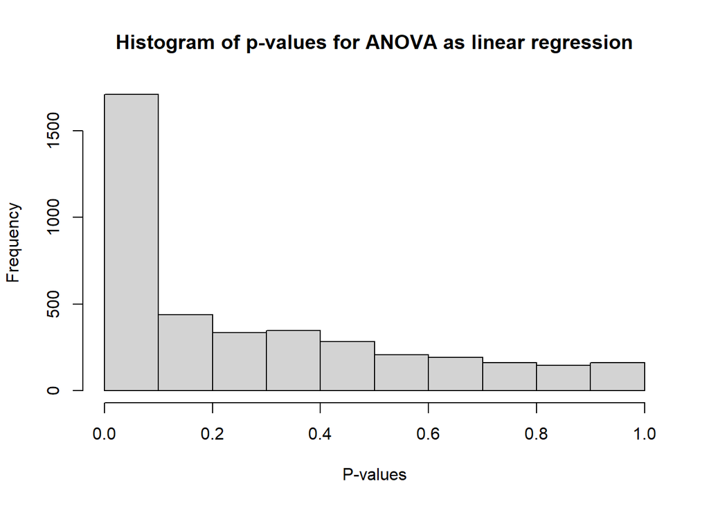

```r
#replicating the time of the sample here.
time_value <- c(rep(2,3), rep(86,3), rep(128,5))

##empty variable to save the p values
aovLR_pVal <- c()


#get each row of data and cast it to numeric
for( i in 1:nrow(myTNorm)){
    myData <- as.numeric(myTNorm[i,] )

    ##  building linear models with myData as the y-variable and time as x-variable
    mylinearmodel1 <- lm(myData ~ time_value, x=TRUE)
    aovLR_pVal <- c(aovLR_pVal, anova(mylinearmodel1)$ "Pr(>F)"[1]) # extracting the p value from the linear model
}
#histogram of the p-values.
hist(aovLR_pVal,xlab = "P-values", ylab ="Frequency",main ="Histogram of p-values for ANOVA as linear regression")
```

```r
#For p <0.05 BH FDR corrected:
aovLR_BH <- p.adjust(aovLR_pVal, method="BH") # using method BH
aovLR_BHpval <- sum(aovLR_BH <0.05) # summing all the p values <0.05
print(paste("The number of genes significant at p-values <0.05 BH FDR corrected for ANOVA as linear regression for time 2 days, 86 days and 128 days is :", aovLR_BHpval))
```

```
## [1] "The number of genes significant at p-values <0.05 BH FDR corrected for ANOVA as linear regression for time 2 days, 86 days and 128 days is : 448"
```

3. Finally, for each row in the spreadsheet perform an ANOVA comparing the three-parameter model from (A) and the two parameter model from (B). Plot out the histogram of all p-values. For how many genes is there a significant difference between these two models at a BH FDR-corrected threshold.

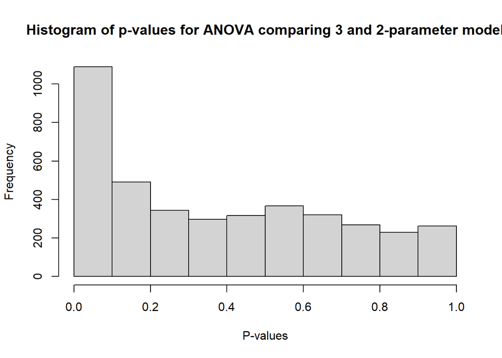

```r
#empty variable to save the p values
pvalue_compare <- c()

#get each row of data and cast it to numeric
for( i in 1:nrow(myTNorm)){
    myData <- as.numeric(myTNorm[i,] )

  anov_3para <- lm(myData ~ categories_value,x=TRUE) # three-parameter model

  anov_2para <- lm(myData ~ time_value, x=TRUE) # two-parameter model

  fullmodel <- sum(residuals(anov_3para)^2) # calculating residual sum for 3 parameter model
  reducemodel <- sum(residuals(anov_2para)^2) # calculating residual sum for 2 parameter model

  #calculating the F value using reduce and full model along with df (n=sample size=> 11-3/11-2)
  F = ((reducemodel - fullmodel)/(1))/(fullmodel/8)

  #Now calculating the p value using pf function along with df1 and df2
  pval <- pf(F, 1,8,lower.tail = FALSE)

  pvalue_compare <- c(pvalue_compare, pval)# saving all p values into an empty variable.

}
hist(pvalue_compare,xlab = "P-values", ylab ="Frequency",main ="Histogram of p-values for ANOVA comparing 3 and 2-parameter model")
```

```r
#For p <0.05 BH FDR corrected:
pval_BH <- p.adjust(pvalue_compare, method="BH")
BHpval <- sum(pval_BH <0.05)
print(paste("The number of genes significantly different between three-parameter and two-parameter model at p-values <0.05 BH FDR corrected is :", BHpval))
```

```
## [1] "The number of genes significantly different between three-parameter and two-parameter model at p-values <0.05 BH FDR corrected is : 51"
```

4. Make three graphs showing the relative abundance of the most significant gene under each of the three ANOVA models. For (A) and (C), the x-axis will the category (day 3, week 12 and week 18) and the y-axis will be the relative abundance. Be sure to properly label and title all graphs and axes. For (B) the x-axis will be time (in days) and the y-axis will be the relative abundance. For the graph of the top hit from (B), include the regression line for the plot from (B).

```r
#empty variables to save the p values from each of the three models.
pValuesOneWayAnova <- vector()
pValuesRegression <- vector()
pValueModelDiff <- vector()

#index of the rows
index <- vector()

categories_value <- c(rep("D2",3), rep("W12",3), rep("W20",5))

for( i in 1:nrow(myTNorm)){

    index[i] <- i # indexing the rows

    #get each row of data and cast it to numeric
    myData <- as.numeric(myTNorm[i,] )

    #---model 1----
    #  building linear models with myData as the y-variable
    mylinearmodel <- lm(myData ~ categories_value, x=TRUE)
    pValuesOneWayAnova <- c(pValuesOneWayAnova, anova(mylinearmodel)$ "Pr(>F)"[1])# extracting the p value from the linear model one-way anova

    #---model 2----
    ##  building linear models with myData as the y-variable
    mylinearmodel1 <- lm(myData ~ time_value, x=TRUE)
    pValuesRegression <- c(pValuesRegression, anova(mylinearmodel1)$ "Pr(>F)"[1])# extracting the p value from the linear model anova as linear regression

  #---model 3----
  fullmodel <- sum(residuals(mylinearmodel)^2)# calculating residual sum for 3 parameter model

  reducemodel <- sum(residuals(mylinearmodel1)^2)  # calculating residual sum for 2 parameter model

  #calculating the F value using reduce and full model along with df (n=sample size=> 11-3/11-2)
  F = ((reducemodel - fullmodel)/(1))/(fullmodel/8)

  #Now calculating the p value using pf function along with df1 and df2
  pval <- pf(F, 1,8,lower.tail = FALSE)
  pValueModelDiff <- c(pValueModelDiff, pval)# saving all p values into an empty variable.

}
#built a dataframe of p values from three models with the index number
myFrame <- data.frame( index, pValuesOneWayAnova,pValuesRegression,pValueModelDiff)
head(myFrame)
```

|  | index | pValuesOneWayAnova | pValuesRegression | pValueModelDiff |
| --- | --- | --- | --- | --- |
| 1 | 1 | 0.9100144653 | 0.754077180 | 0.763454243 |
| 2 | 2 | 0.2975763978 | 0.117279334 | 0.734542332 |
| 3 | 3 | 0.0006747441 | 0.028396643 | 0.001993919 |
| 4 | 4 | 0.0087588766 | 0.005113998 | 0.155630072 |
| 5 | 5 | 0.3013518244 | 0.890539086 | 0.134402540 |
| 6 | 6 | 0.0271221645 | 0.023800039 | 0.130603110 |

- 1. boxplot for one way ANOVA:

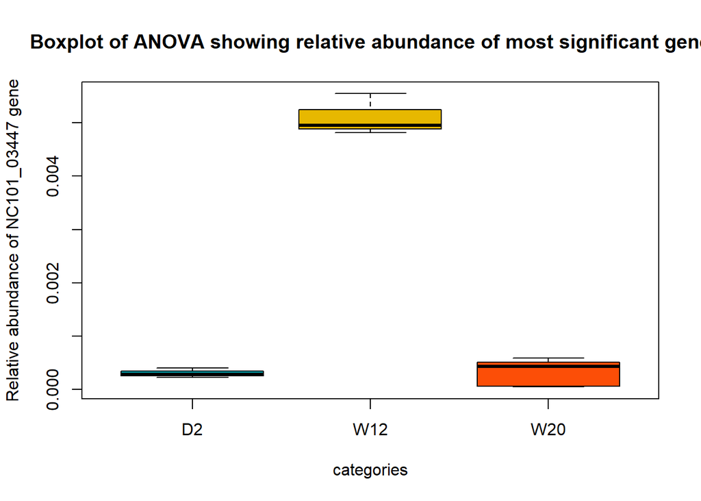

```r
# Here, we are ordering the p values of one way ANOVA:
myFrame <- myFrame[ order(myFrame$pValuesOneWayAnova),]

# in this boxplot, we are taking the sample values of a most significant gene based on the ordered index number on x axis and y being the abundance of the gene
boxplot( as.numeric( myTNorm[ myFrame$index[1],]) ~ categories_value,xlab = "categories", ylab ="Relative abundance of NC101_03447 gene", main="Boxplot of ANOVA showing relative abundance of most significant gene",col = c("#00AFBB", "#E7B800", "#FC4E07") )
```

- 2. plot with regression line:

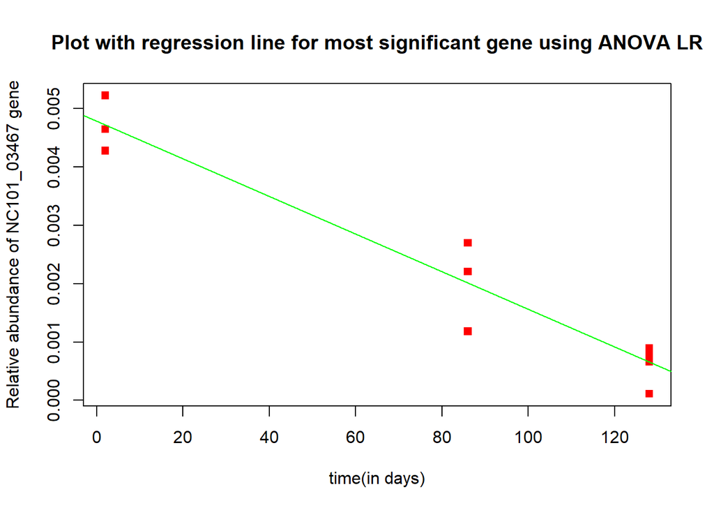

```r
# Here, we are ordering the p values of one way ANOVA as linear regression:
myFrame <- myFrame[ order(myFrame$pValuesRegression), ]

#In this plot, we are taking the sample values of a most significant gene based on the ordered index number on x axis and y being the abundance of the gene
plot(time_value,as.numeric( myTNorm[ myFrame$index[1],]),xlab = "time(in days)", ylab ="Relative abundance of NC101_03467 gene",main="Plot with regression line for most significant gene using ANOVA LR",col="red",pch = 15)
# calculating the linear model to add the regression line
mylm <- lm(as.numeric( myTNorm[ myFrame$index[1],])~time_value)
abline(mylm, col="green") # This adds the regression line to the plot
```

- 3. Boxplot for model difference:

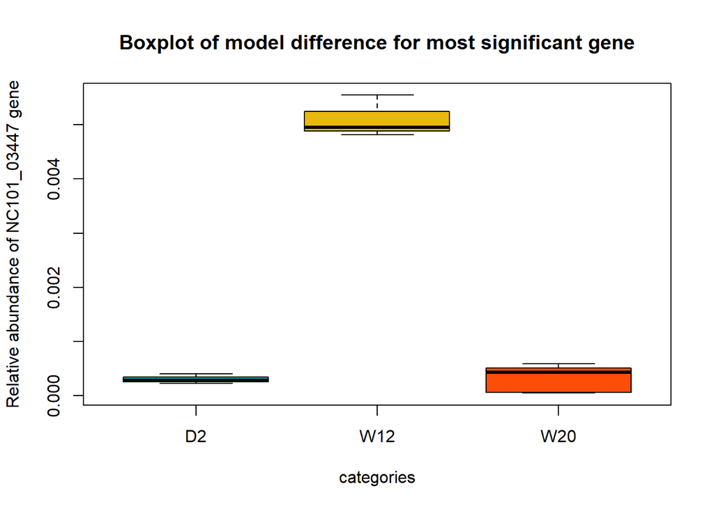

```r
# Here, we are ordering the p values of model difference:
myFrame <- myFrame[ order(myFrame$pValueModelDiff), ]

# In this boxplot, we are taking the sample values of a most significant gene based on the ordered index number on x axis and y being the abundance of the gene
boxplot( as.numeric( myTNorm[ myFrame$index[1],]) ~ categories_value,xlab = "categories", ylab ="Relative abundance of NC101_03447 gene", main ="Boxplot of model difference for most significant gene",col = c("#01AFBB", "#E7B810", "#FC4E08")  )
```

5. Overall, do you think the three parameter model in (A) or the two-parameter model in (B) is more appropriate for these data? Justify your answer.
- From my perspective, three parameter model is more appropriate for these data because in the full model/ three parameter we assume that each observation is a function of a specific group mean, so there are more parameters (one for each group’s mean–hence “full”).The full model appears to describe the trend in the data better than the reduced model. Whereas in the reduced model we assume that each observation is a function of the grand mean, so there are fewer parameters (hence, “reduced”) to compare. A reduced model does not include all the possible terms to be used for these data.The 2 parameter model makes assumptions of linearity that are not appropriate for a substantial subset of the genes.